# Final 216 project_Junxiao

## Random Forests

The Ranger model appears to have a low OOB prediction error (Brier s.) of 0.090, indicating that it has a good predictive performance. The Random Forest model appears to be the best performing model with a test accuracy of 0.902, sensitivity of 0.0069, and specificity of 0.999. It correctly classified the highest percentage of observations in the test set compared to the other models. The estimated AUC for the XGBoost model is 0.5, which suggests that the model is not effective at discriminating between positive and negative cases of skin cancer.

```r
# Fit a random forest to training data
library(ranger)
rf_mdl <- ranger(as.factor(CHCSCNCR) ~ ., data=dat3_train, mtry=5, probability=T, importance="impurity")
rf_mdl$prediction.error# The out of bag (OOB) error for the RF (OOB error estimate are a clever way that random forests gets honest error estimates i.e. not over-fitted)
```

```
## [1] 0.09030659
```

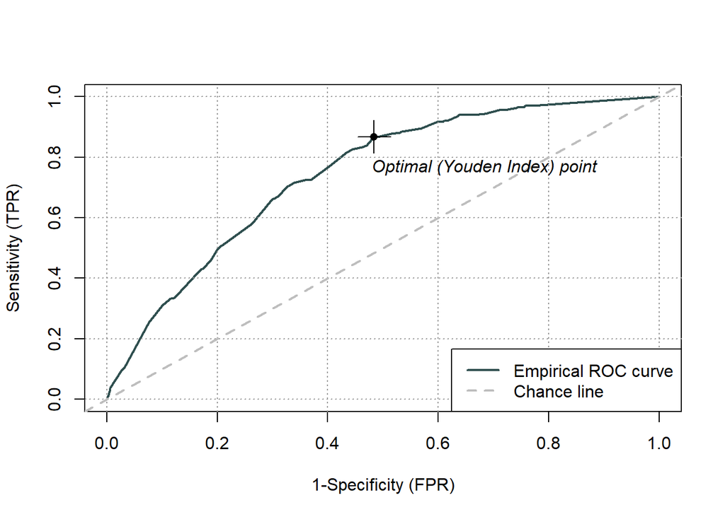

```r
# Fit the model to testing data
library(ROCit)
rf_pred <- predict(rf_mdl, data = dat3_test)
prostate_roc <- rocit(rf_pred$predictions[,2], class=dat3_test$CHCSCNCR)
plot(prostate_roc)
```

```r
ciAUC(prostate_roc)
```

```
##
##    estimated AUC : 0.743671290487476
##    AUC estimation method : empirical
##
##    CI of AUC
##    confidence level = 95%
##    lower = 0.716092360920392     upper = 0.771250220054561
```

```r
# Predict class probabilities for test set using Random Forest model
rf_probs <- predict(rf_mdl, data = dat3_test)

# Convert probabilities into predicted class labels using a threshold
rf_preds <- ifelse(rf_probs$predictions[, 2] > 0.5, "Yes", "No")

# Calculate classification accuracy
rf_xt <- table(true_disease = dat3_test$CHCSCNCR, predictions = rf_preds)
rf_accuracy <- sum(diag(rf_xt)) / sum(rf_xt)

# Calculate sensitivity and specificity
rf_sens <- rf_xt[2, 2] / sum(rf_xt[2, ])
rf_spec <- rf_xt[1, 1] / sum(rf_xt[1, ])

# Print results
print(paste("Random Forest Test accuracy:", round(rf_accuracy, 4)))
```

```
## [1] "Random Forest Test accuracy: 0.902"
```

```r
print(paste("Random Forest Sensitivity:", round(rf_sens, 4)))
```

```
## [1] "Random Forest Sensitivity: 0.0069"
```

```r
print(paste("Random Forest Specificity:", round(rf_spec, 4)))
```

```
## [1] "Random Forest Specificity: 0.999"
```

```r
# Based on the variable importance measures in the random forest, age was most important. 100% of predictors have a nonzero variable importance.
factor_list <- colnames(dat3_test)[-1]
top_rf_factor <- factor_list[which.max(rf_mdl$variable.importance)]
top_rf_factor
```

```
## [1] "X_AGE_G"
```

```r
mean(rf_mdl$variable.importance != 0)
```

```
## [1] 1
```

## Accuracy, sensitivity, and specificity of the four models

```r
# Table with the test accuracy, sensitivity, and specificity of the four models
results <- data.frame(Model = c("Logistic Regression", "Linear Discriminant Analysis", "Elastic Net Regression", "Random Forest"),
                      Test_Accuracy = c(accuracy, accuracylda2, accuracy2, rf_accuracy),
                      Sensitivity = c(sens, senslda2,sens2, rf_sens),
                      Specificity = c(spec, speclda2, spec2, rf_spec))

# Print the table
print(results)
```

```
##                          Model Test_Accuracy Sensitivity Specificity
## 1          Logistic Regression     0.7321712 0.597222222   0.7468005
## 2 Linear Discriminant Analysis     0.8988001 0.200000000   0.9027778
## 3       Elastic Net Regression     0.6964003 0.655092593   0.7008783
## 4                Random Forest     0.9019697 0.006944444   0.9989962
```

## Gradient boosted trees

```r
# Fit a gradient boosted tree to see how variable importance can change.
library(xgboost)
library(dplyr)

xgbDatTrain <- xgb.DMatrix(as.matrix(dat3_train[, -which(names(dat3_train) == "CHCSCNCR")]), label=ifelse(dat3_train$CHCSCNCR == "normal", 1, 0))
xgbDatTest <- xgb.DMatrix(as.matrix(dat3_test[, -which(names(dat3_test) == "CHCSCNCR")]), label=ifelse(dat3_test$CHCSCNCR == "normal", 1, 0))

xgb_mdl <- xgboost(xgbDatTrain, nrounds = 1000, verbose = 0, params = list(objective="binary:logistic", eta=0.1, max_depth=1))
```

```r
# The AUC of this fitted model in testing data
predTest <- predict(xgb_mdl, newdata = xgbDatTest)
xgb_roc <- rocit(predTest, ifelse(dat3_test$CHCSCNCR == 1, 1, 0))
ciAUC(xgb_roc)
```

```
##
##    estimated AUC : 0.5
##    AUC estimation method : empirical
##
##    CI of AUC
##    confidence level = 95%
##    lower = 0.471337485496804     upper = 0.528662514503196
```

```r
# The most important predictor selected by xgb is sex. It is not the same predictor selected by the random forest.
predContr <- predict(xgb_mdl, newdata = xgbDatTest, predcontrib = T)
predContr <- as.data.frame(predContr)
colnames(predContr) <- factor_list

predContrMean <- colMeans(predContr)
predContrMean <- sort(predContrMean, decreasing = T)
predContrMean[1] # top factor is sex -- not the same
```

```
## SEX
##   0
```

# Discussion

In conclusion, the results of this study suggest that random forest is the best-performing model for predicting skin cancer based on demographic and clinical features. However, the low sensitivity values suggest that the models should be improved to correctly identify individuals with skin cancer. Further studies with larger sample sizes and additional features should be conducted to improve the performance of the models.

This study has several limitations. Firstly, the dataset used in the study is relatively small and the sample size could be increased to improve the accuracy of the models. Secondly, the dataset contains a significant number of missing values, which may have affected the performance of the models. Thirdly, the models tested only include a limited number of features and the addition of more features could improve the performance of the models.

## References

[1] American Cancer Society. (2021). Key Statistics for Skin Cancer. Retrieved from https://www.cancer.org/cancer/skin-cancer/about/key-statistics.html

[2] Codella, N. C., Gutman, D., Celebi, M. E., Helba, B., Marchetti, M. A., Dusza, S. W., … & Halpern, A. (2019). Skin lesion analysis toward melanoma detection: A challenge at the 2017 International Symposium on Biomedical Imaging (ISBI), hosted by the International Skin Imaging Collaboration (ISIC). arXiv preprint arXiv:1902.03368.